# Biopsy Biomarker Variable Selection

## Summary

The 3 models: **Lasso regression, Elastic net regularization, Support Vector Machine** have the smallest misclassification rate 0.0366 and the highest Accuracy 0.9634. For the models **Lasso regression, Elastic net regularization**, the Receiver Operating Characteristics (ROC) Curves are shown below and the optimal cutoff values are 0.42 and 0.34.

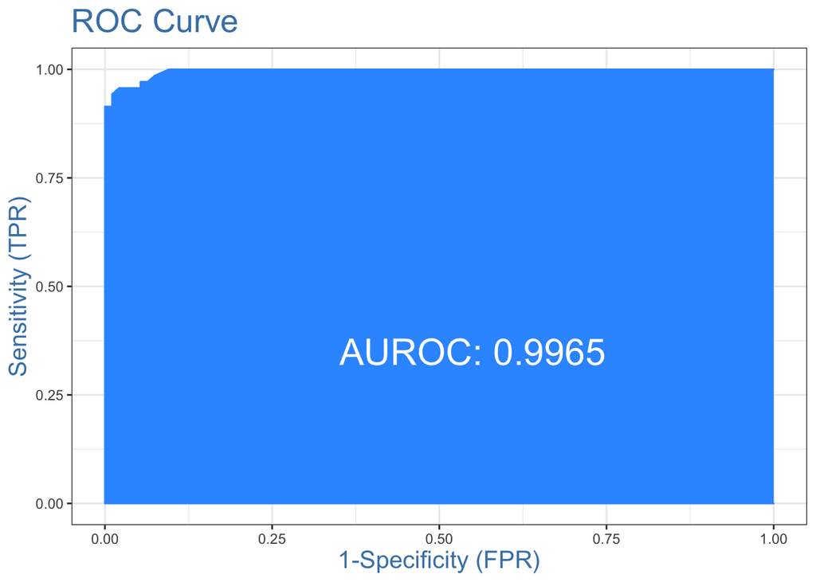

```r
## ROC Curve of Lasso regression
plotROC(y_test, lasso.probs)
```

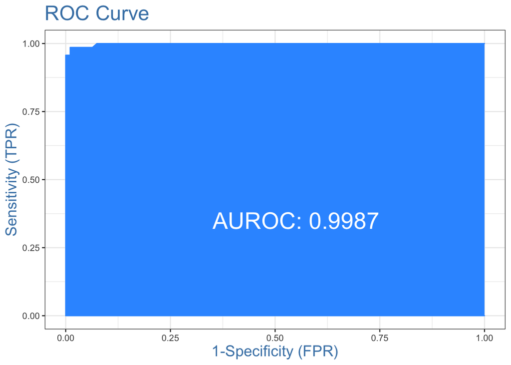

```r
## ROC Curve of Elastic net regularization
plotROC(y_test, enet.probs)
```

## Conclusions

In addition, other machine learning algorithms are also potential candidates, such as SVM and PCA, which have an accuracy of more than 95%. However, on the one hand, the machine learning model is difficult to interpret, and on the other hand, it is more complicated when building the model (parameter selection, cross-validation, etc.), so in terms of practicality, penalized regression may be more advantageous.

All in all, this task is a very interesting and challenging task. In terms of content, the comparison of more than 10 models is comprehensive, but conversely, limited by time and experience, the depth and complexity of each model will be reduced. I spent three nights processing (around 16 hours). Among them, Cutoff analysis and AUC are rarely used in practice. But through this task, I can make a comprehensive comparison and summary of the classification algorithms that I am familiar with, which really benefited me a lot.